# final_project

Oleksii Davydenko

2018/1/13

### The Data

The American Time Use Survey (ATUS) is a time-use survey of Americans, which is sponsored by the Bureau of Labor Statistics (BLS) and conducted by the U.S. Census Bureau. Respondents of the survey are asked to keep a diary for one day carefully recording the amount of time they spend on various activities including working, leisure, childcare, and household activities. The survey has been conducted every year since 2003.

Included in the data are main demographic variables such as respondents’ age, sex, race, marital status, and education. The data also includes detailed income and employment information for each respondent. While there are some slight changes to the survey each year, the main questions asked stay the same. You can find the data dictionaries for each year on https://www.bls.gov/tus/dictionaries.htm

### Accessing the Data

There are multiple ways to access the ATUS data; however, for this project, you’ll get the raw data directly from the source. The data for each year can be found at https://www.bls.gov/tus/#data. Once there, there is an option of downloading a multi-year file, which includes data for all of the years the survey has been conducted, but **for the purposes of this project, let’s just look at the data for 2016**. Under **Data Files**, click on `American Time Use Survey--2016 Microdata files`.

You will be brought to a new screen. Scroll down to the section **2016 Basic ATUS Data Files**. Under this section, you’ll want to **click to download** the following two files: `ATUS 2016 Activity summary file (zip)` and `ATUS-CPS 2016 file (zip)`.

- `ATUS 2016 Activity summary file (zip)` contains information about the total time each ATUS respondent spent doing each activity listed in the survey. The activity data includes information such as activity codes, activity start and stop times, and locations.
- `ATUS-CPS 2016 file (zip)` contains information about each household member of all individuals selected to participate in the ATUS.

Once they’ve been downloaded, you’ll need to **unzip the files**. Once unzipped, you will see the dataset in a number of different file formats including `.sas`, `.sps`, and `.dat` files. **We’ll be working with the .dat files.**

### Importing data

```r
atus.cps <- read.delim('data/raw_data/atuscps_2016.dat', sep=",")
atus.sum <- read.delim('data/raw_data/atussum_2016.dat', sep=",")
atus.all <- atus.sum %>%
  left_join(atus.cps %>% filter(TULINENO==1), by = c("TUCASEID"))
```

### Exploratory Analysis of Child Care Data

```r
#head(atus.sum)
#head(atus.cps)
# average time socializing and communicating with others
mean(atus.all$t120101)
```

```
## [1] 38.06481
```

```r
# childcare is the sum of all activities starting with 't03'
atus.all <- atus.all %>%
    mutate(CHILDCARE = t030101+t030102+t030103+t030104+t030105
           +t030106+t030108+t030109+t030110+t030111+t030112+t030199)
```

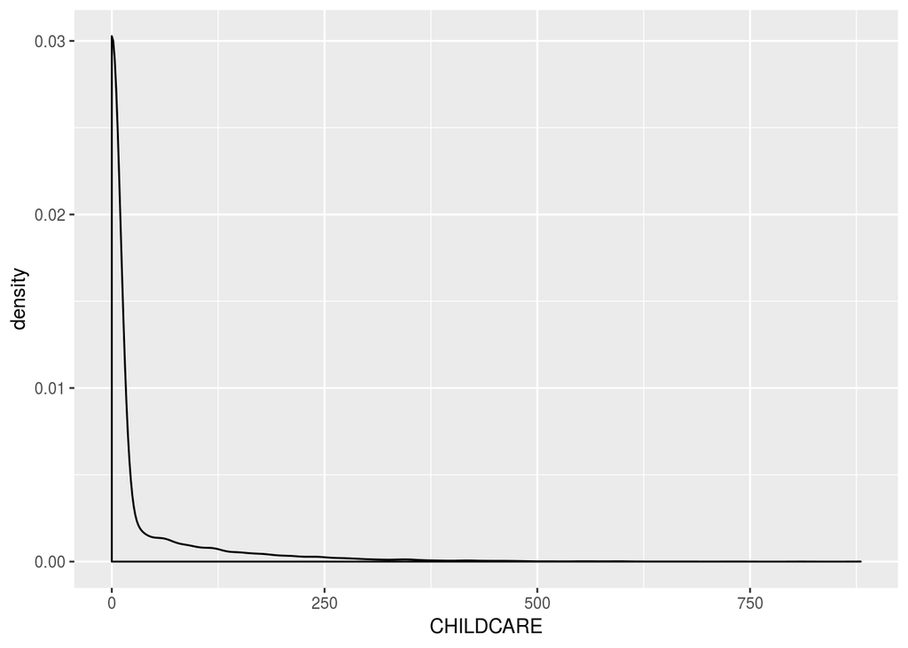

```r
ggplot(atus.all) +
    geom_density(aes(x = CHILDCARE))
```

```r
atus.all %>%
    group_by(TESEX) %>% # 1 = male, 2 = female
    summarize(n_minutes=mean(CHILDCARE))
```

```
## # A tibble: 2 x 2
##   TESEX n_minutes
##   <int>     <dbl>
## 1     1      19.0
## 2     2      33.2
```

```r
## replace -1 in the variable TRDPFTPT with NA.
atus.all <- atus.all %>% mutate(TRDPFTPT = replace(TRDPFTPT, TRDPFTPT == -1, NA))
```

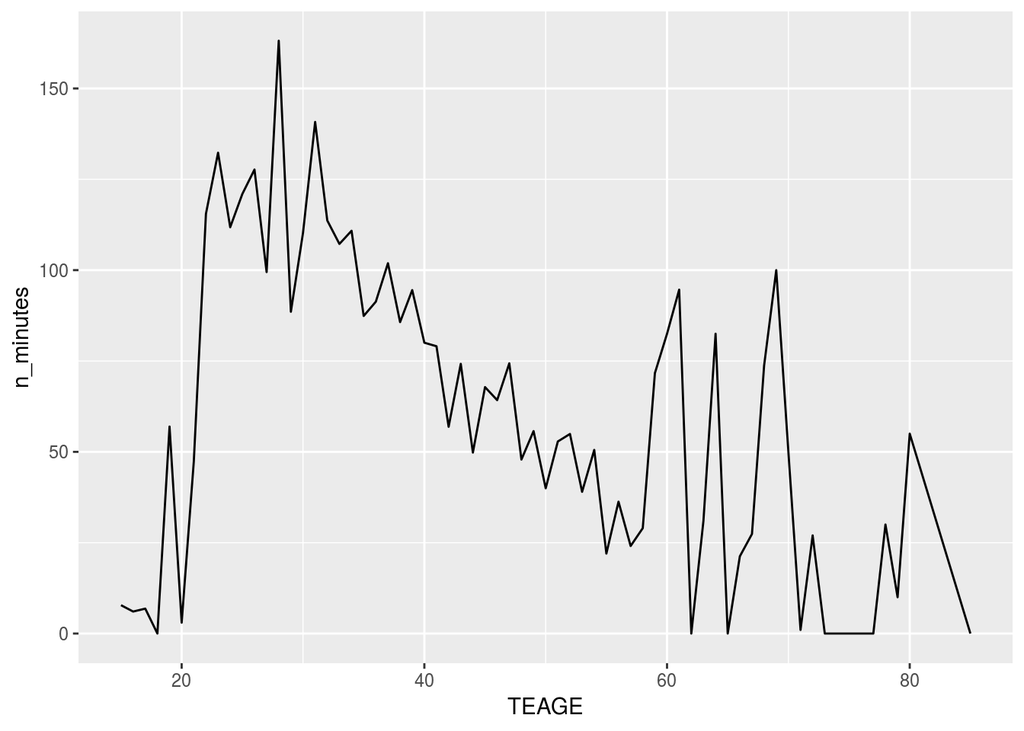

```r
## Exclude households without children
atus.all <- atus.all %>%
  filter(TRCHILDNUM > 1)
## Do younger parents spend more time with their children?
care_by_age <- atus.all %>%
  group_by(TEAGE) %>%
  dplyr::summarize(n_minutes = mean(CHILDCARE))
#care_by_age
ggplot(data = care_by_age) +
  geom_line(aes(x = TEAGE, y = n_minutes))
```

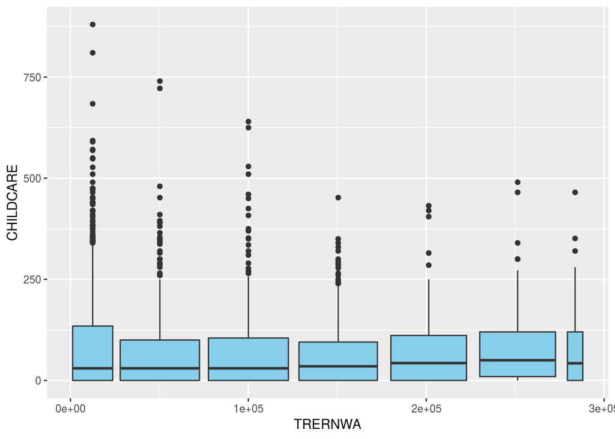

```r
## Do richer people spend more time with their children compared to poorer people?
ggplot(atus.all, aes(x = TRERNWA, y = CHILDCARE)) +
  geom_boxplot(fill="skyblue", aes(group = cut_width(TRERNWA, 50000.0)))
```

```r
## Do married couples spend more time with their children compared to single parents?
table(atus.all$TRSPPRES)
```

```
##
##    1    2    3
## 1743   95  694
```

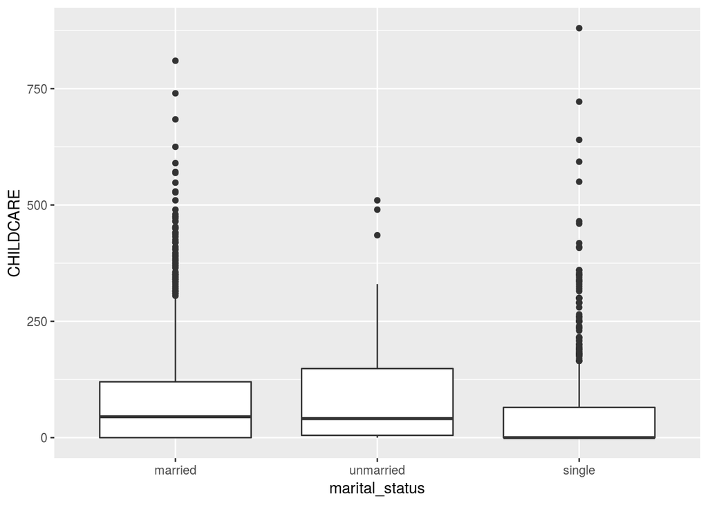

```r
atus.all <- atus.all %>%
  mutate(marital_status = factor(TRSPPRES))
library(plyr)
marital_factor <- mapvalues(atus.all$marital_status, from = c("1", "2", "3"),
                            to = c("married", "unmarried", "single"))
atus.all <- atus.all %>%
  mutate(marital_status = marital_factor)
ggplot(atus.all, aes(x = marital_status, y = CHILDCARE)) +
  geom_boxplot()
```

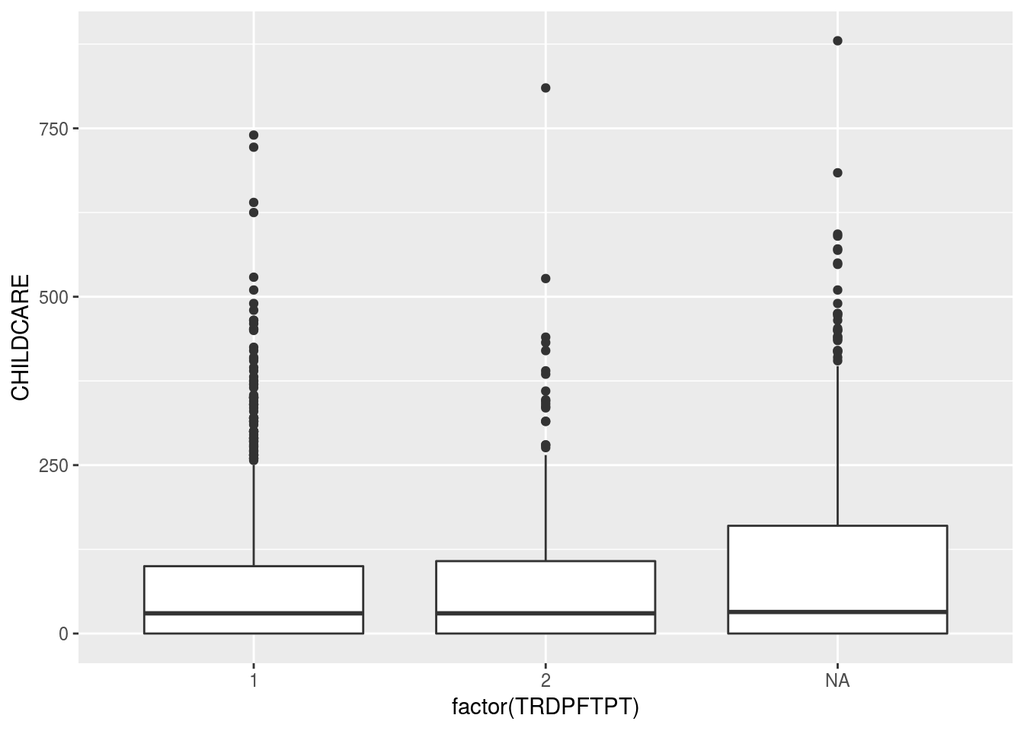

```r
## Do full-time workers spend more time with their children compared to part-time workers?
employment_factor <- mapvalues(atus.all$TRDPFTPT, from = c("1", "2"),
                            to = c("full-time", "part-time"))
ggplot(atus.all, aes(x = factor(TRDPFTPT), y = CHILDCARE)) +
  geom_boxplot()
```

### Regression Analysis

```r
## Run a linear regression of marital status, age, sex,
#  number of children (18 or younger), earnings,
#  and full-time versus part-time status
reg_model <- lm(CHILDCARE ~ TEAGE + TESEX + TRCHILDNUM +
                  HEFAMINC + TRDPFTPT, data = atus.all)
summary(reg_model)
```

```
##
## Call:
## lm(formula = CHILDCARE ~ TEAGE + TESEX + TRCHILDNUM + HEFAMINC +
##     TRDPFTPT, data = atus.all)
##
## Residuals:
##     Min      1Q  Median      3Q     Max
## -111.65  -60.41  -35.62   31.93  732.15
##
## Coefficients:
##             Estimate Std. Error t value Pr(>|t|)
## (Intercept)  61.4941    18.0023   3.416  0.00065 ***
## TEAGE        -0.9998     0.2544  -3.931 8.79e-05 ***
## TESEX        23.0451     4.7045   4.899 1.05e-06 ***
## TRCHILDNUM    1.4842     2.9800   0.498  0.61850
## HEFAMINC      1.7841     0.6353   2.808  0.00504 **
## TRDPFTPT    -11.4524     5.7484  -1.992  0.04649 *
## ---
## Signif. codes:  0 '***' 0.001 '**' 0.01 '*' 0.05 '.' 0.1 ' ' 1
##
## Residual standard error: 95.17 on 1832 degrees of freedom
##   (694 observations deleted due to missingness)
## Multiple R-squared:  0.02411,    Adjusted R-squared:  0.02145
## F-statistic: 9.052 on 5 and 1832 DF,  p-value: 1.633e-08
```

### Exploratory Analysis of Age and Activities

```r
atus.wide <- atus.all %>%
  mutate(act01 = rowSums(atus.all[, grep("t01", names(atus.all))]),
         act02 = rowSums(atus.all[, grep("t02", names(atus.all))]),
         act03 = rowSums(atus.all[, grep("t03", names(atus.all))]),
         act04 = rowSums(atus.all[, grep("t04", names(atus.all))]),
         act05 = rowSums(atus.all[, grep("t05", names(atus.all))]),
         act06 = rowSums(atus.all[, grep("t06", names(atus.all))]),
         act07 = rowSums(atus.all[, grep("t07", names(atus.all))]),
         act08 = rowSums(atus.all[, grep("t08", names(atus.all))]),
         act09 = rowSums(atus.all[, grep("t09", names(atus.all))]),
         act10 = rowSums(atus.all[, grep("t10", names(atus.all))]),
         act11 = rowSums(atus.all[, grep("t11", names(atus.all))]),
         act12 = rowSums(atus.all[, grep("t12", names(atus.all))]),
         act13 = rowSums(atus.all[, grep("t13", names(atus.all))]),
         act14 = rowSums(atus.all[, grep("t14", names(atus.all))]),
         act15 = rowSums(atus.all[, grep("t15", names(atus.all))]),
         act16 = rowSums(atus.all[, grep("t16", names(atus.all))]),
         # act17 = , there is no category 17 in the data
         act18 = rowSums(atus.all[, grep("t18", names(atus.all))])
         ) %>%
  select(TUCASEID, TEAGE, HEFAMINC, starts_with("act"))
summary(atus.wide)
```

```
##     TUCASEID             TEAGE          HEFAMINC        act01
##  Min.   :2.016e+13   Min.   :15.00   Min.   : 1.0   Min.   :   0.0
##  1st Qu.:2.016e+13   1st Qu.:31.00   1st Qu.:10.0   1st Qu.: 480.8
##  Median :2.016e+13   Median :38.00   Median :13.0   Median : 555.0
##  Mean   :2.016e+13   Mean   :37.07   Mean   :11.9   Mean   : 565.9
##  3rd Qu.:2.016e+13   3rd Qu.:44.00   3rd Qu.:15.0   3rd Qu.: 635.0
##  Max.   :2.016e+13   Max.   :85.00   Max.   :16.0   Max.   :1410.0
##      act02           act03            act04             act05
##  Min.   :  0.0   Min.   :  0.00   Min.   :  0.000   Min.   :   0.0
##  1st Qu.: 18.0   1st Qu.:  0.00   1st Qu.:  0.000   1st Qu.:   0.0
##  Median : 80.0   Median : 40.50   Median :  0.000   Median :   0.0
##  Mean   :121.3   Mean   : 87.09   Mean   :  3.825   Mean   : 185.2
##  3rd Qu.:180.0   3rd Qu.:130.00   3rd Qu.:  0.000   3rd Qu.: 445.0
##  Max.   :810.0   Max.   :880.00   Max.   :870.000   Max.   :1290.0
##      act06             act07            act08             act09
##  Min.   :   0.00   Min.   :  0.00   Min.   :  0.000   Min.   :  0.0000
##  1st Qu.:   0.00   1st Qu.:  0.00   1st Qu.:  0.000   1st Qu.:  0.0000
##  Median :   0.00   Median :  0.00   Median :  0.000   Median :  0.0000
##  Mean   :  24.78   Mean   : 25.56   Mean   :  2.932   Mean   :  0.6078
##  3rd Qu.:   0.00   3rd Qu.: 30.00   3rd Qu.:  0.000   3rd Qu.:  0.0000
##  Max.   :1000.00   Max.   :475.00   Max.   :290.000   Max.   :150.0000
##      act10              act11            act12            act13
##  Min.   :  0.0000   Min.   :  0.00   Min.   :   0.0   Min.   :   0.00
##  1st Qu.:  0.0000   1st Qu.: 30.00   1st Qu.:  85.0   1st Qu.:   0.00
##  Median :  0.0000   Median : 60.00   Median : 180.0   Median :   0.00
##  Mean   :  0.3397   Mean   : 65.75   Mean   : 217.5   Mean   :  23.85
##  3rd Qu.:  0.0000   3rd Qu.: 90.00   3rd Qu.: 310.0   3rd Qu.:   0.00
##  Max.   :240.0000   Max.   :450.00   Max.   :1263.0   Max.   :1260.00
##      act14            act15            act16             act18
##  Min.   :  0.00   Min.   :  0.00   Min.   :  0.000   Min.   :  0.00
##  1st Qu.:  0.00   1st Qu.:  0.00   1st Qu.:  0.000   1st Qu.: 30.00
##  Median :  0.00   Median :  0.00   Median :  0.000   Median : 62.00
##  Mean   : 12.03   Mean   :  8.81   Mean   :  4.105   Mean   : 78.27
##  3rd Qu.:  0.00   3rd Qu.:  0.00   3rd Qu.:  0.000   3rd Qu.:105.00
##  Max.   :713.00   Max.   :755.00   Max.   :235.000   Max.   :898.00
```

```r
## use code to convert the wide format to long
atus.long <- atus.wide %>% melt(., id.vars = c("TUCASEID", "TEAGE", "HEFAMINC"))
names(atus.long) <- c("TUCASEID", "TEAGE", "HEFAMINC", "ACTIVITY", "MINS")
summary(atus.long)
```

```
##     TUCASEID             TEAGE          HEFAMINC       ACTIVITY
##  Min.   :2.016e+13   Min.   :15.00   Min.   : 1.0   act01  : 2532
##  1st Qu.:2.016e+13   1st Qu.:31.00   1st Qu.:10.0   act02  : 2532
##  Median :2.016e+13   Median :38.00   Median :13.0   act03  : 2532
##  Mean   :2.016e+13   Mean   :37.07   Mean   :11.9   act04  : 2532
##  3rd Qu.:2.016e+13   3rd Qu.:44.00   3rd Qu.:15.0   act05  : 2532
##  Max.   :2.016e+13   Max.   :85.00   Max.   :16.0   act06  : 2532
##                                                     (Other):27852
##       MINS
##  Min.   :   0.00
##  1st Qu.:   0.00
##  Median :   0.00
##  Mean   :  83.98
##  3rd Qu.:  75.00
##  Max.   :1410.00
##
```

```r
glimpse(atus.long)
```

```
## Observations: 43,044
## Variables: 5
## $ TUCASEID <dbl> 2.01601e+13, 2.01601e+13, 2.01601e+13, 2.01601e+13, 2.0…
## $ TEAGE    <int> 24, 31, 16, 43, 34, 39, 35, 54, 68, 32, 43, 50, 17, 44,…
## $ HEFAMINC <int> 4, 8, 5, 16, 5, 11, 15, 13, 13, 14, 16, 15, 10, 13, 8, …
## $ ACTIVITY <fct> act01, act01, act01, act01, act01, act01, act01, act01,…
## $ MINS     <dbl> 1060, 655, 620, 445, 665, 760, 838, 555, 481, 580, 573,…
```

#### How does time doing certain activities vary by age?

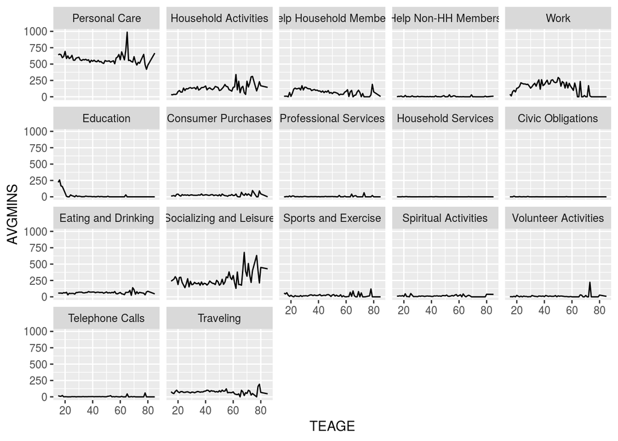

```r
# summarize average time per activity for each age
avgmin_data <- atus.long %>%
    group_by(ACTIVITY, TEAGE) %>%
    dplyr::summarise(AVGMINS = mean(MINS))
activity_names <- c("Personal Care",
                    "Household Activities",
                    "Help Household Members",
                    "Help Non-HH Members",
                    "Work",
                    "Education",
                    "Consumer Purchases",
                    "Professional Services",
                    "Household Services",
                    "Civic Obligations",
                    "Eating and Drinking",
                    "Socializing and Leisure",
                    "Sports and Exercise",
                    "Spiritual Activities",
                    "Volunteer Activities",
                    "Telephone Calls",
                    "Traveling")
levels(avgmin_data$ACTIVITY) <- activity_names
# bin ages into groups
avgmin_data <- cbind(avgmin_data, AGE_BIN=cut(avgmin_data$TEAGE,
                                              breaks=c(14,25,35,45,55,65,75,85)))
avgmin_data %>% ggplot() +
  geom_line(aes(x = TEAGE, y = AVGMINS)) +
  facet_wrap(. ~ ACTIVITY)
```